# Programming Languages für Data Science

Major Assignment: Flight Analysis - Data Exploration Christmas Data

Christian Roth & Andreas Waßmus

22.10.2019

# 1 Data Exploration Christmas Flights 2015

## 1.1 Libraries and Data

```r
library(tidyverse)
library(readr)
library(DataExplorer)
```

## 1.2 Loading the data:

**Christmas15:**

```r
christmas15 <- read_csv( file=( "./data/cleandata/christmas15.csv"))
```

**ChristmasDay15:**

```r
christmasDay15 <- read_csv( file=( "./data/cleandata/christmasDay15.csv"))
```

Check data:

```r
head(christmas15)
```

```
## # A tibble: 6 x 34
##      X1 ORIGIN_AIRPORT AIRLINE  YEAR MONTH   DAY DAY_OF_WEEK FLIGHT_NUMBER
##   <dbl> <chr>          <chr>   <dbl> <dbl> <dbl>       <dbl>         <dbl>
## 1     1 ABE            EV       2015    12    26           6          5579
## 2     2 ABE            EV       2015    12    24           4          5579
## 3     3 ABE            EV       2015    12    26           6          6021
## 4     4 ABE            EV       2015    12    25           5          5579
## 5     5 ABE            EV       2015    12    23           3          5579
## 6     6 ABE            EV       2015    12    23           3          6144
## # … with 26 more variables: TAIL_NUMBER <chr>, DESTINATION_AIRPORT <chr>,
## #   SCHEDULED_DEPARTURE <chr>, DEPARTURE_TIME <chr>,
## #   DEPARTURE_DELAY <dbl>, TAXI_OUT <dbl>, WHEELS_OFF <chr>,
## #   SCHEDULED_TIME <dbl>, ELAPSED_TIME <dbl>, AIR_TIME <dbl>,
## #   DISTANCE <dbl>, WHEELS_ON <chr>, TAXI_IN <dbl>,
## #   SCHEDULED_ARRIVAL <chr>, ARRIVAL_TIME <chr>, ARRIVAL_DELAY <dbl>,
## #   DIVERTED <dbl>, CANCELLED <dbl>, AIRLINE.y <chr>, AIRPORT <chr>,
## #   CITY <chr>, STATE <chr>, COUNTRY <chr>, LATITUDE <dbl>,
## #   LONGITUDE <dbl>, DEPARTURE_DATE <date>
```

```r
head(christmasDay15)
```

```
## # A tibble: 6 x 34
##      X1 ORIGIN_AIRPORT AIRLINE  YEAR MONTH   DAY DAY_OF_WEEK FLIGHT_NUMBER
##   <dbl> <chr>          <chr>   <dbl> <dbl> <dbl>       <dbl>         <dbl>
## 1     1 ABQ            B6       2015    12    24           4            66
## 2     2 ABQ            B6       2015    12    25           5            66
## 3     3 ABQ            B6       2015    12    26           6            66
## 4     4 ABQ            B6       2015    12    23           3            66
## 5     5 ATL            DL       2015    12    26           6           843
## 6     6 ATL            DL       2015    12    24           4           478
## # … with 26 more variables: TAIL_NUMBER <chr>, DESTINATION_AIRPORT <chr>,
## #   SCHEDULED_DEPARTURE <chr>, DEPARTURE_TIME <chr>,
## #   DEPARTURE_DELAY <dbl>, TAXI_OUT <dbl>, WHEELS_OFF <chr>,
## #   SCHEDULED_TIME <dbl>, ELAPSED_TIME <dbl>, AIR_TIME <dbl>,
## #   DISTANCE <dbl>, WHEELS_ON <chr>, TAXI_IN <dbl>,
## #   SCHEDULED_ARRIVAL <chr>, ARRIVAL_TIME <chr>, ARRIVAL_DELAY <dbl>,
## #   DIVERTED <dbl>, CANCELLED <dbl>, AIRLINE.y <chr>, AIRPORT <chr>,
## #   CITY <chr>, STATE <chr>, COUNTRY <chr>, LATITUDE <dbl>,
## #   LONGITUDE <dbl>, DEPARTURE_DATE <date>
```

How many flights are in the two data sets:

```r
nrow(christmas15)
```

```
## [1] 56246
```

```r
nrow(christmasDay15)
```

```
## [1] 1299
```

# 2. Data Exploration Christmas Flights 2015

Quick Introduction christmas15 dataset: (with DataExplorer, source: https://cran.r-project.org/web/packages/DataExplorer/vignettes/dataexplorer-intro.html)

```r
introduce(christmas15)
```

```
## # A tibble: 1 x 9
##    rows columns discrete_columns continuous_colu… all_missing_col…
##   <int>   <int>            <int>            <int>            <int>
## 1 56246      34               16               18                0
## # … with 4 more variables: total_missing_values <int>,
## #   complete_rows <int>, total_observations <int>, memory_usage <dbl>
```

Quick Visualization of the metrics of the data and check missing values:

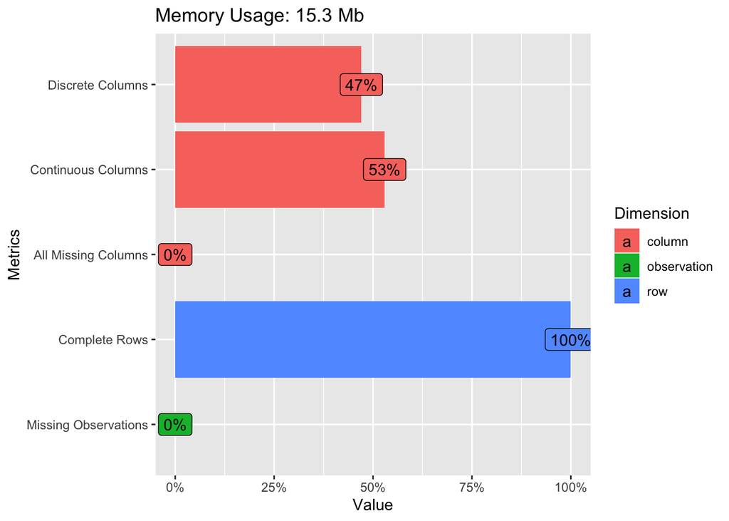

```r
plot_intro(christmas15)
```

With the following histograms you will get first insights in the distribution of each feature.

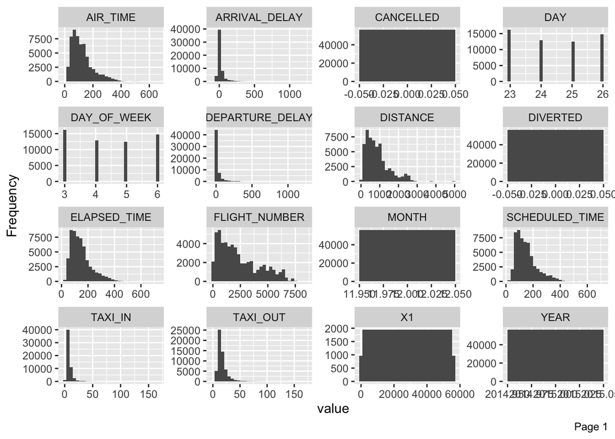

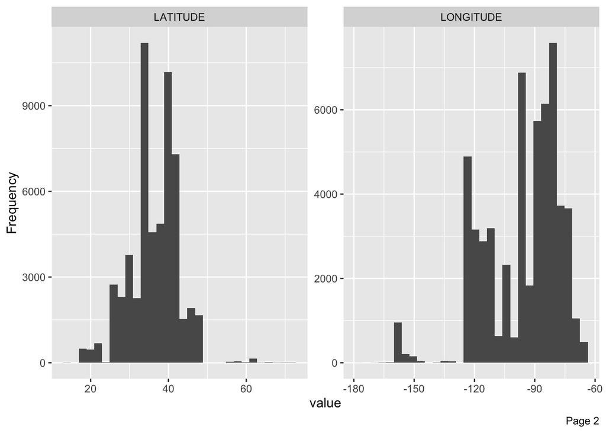

```r
plot_histogram(christmas15, binary_as_factor = TRUE,
  geom_histogram_args = list(bins = 30L), title = NULL,
  theme_config = list(), nrow = 4L,
  ncol = 4L, parallel = FALSE)
```

**Statistics on ARRIVAL_DELAY at Christmas (1)**

```r
summary(christmas15$ARRIVAL_DELAY, na.rm = TRUE)
```

```
##    Min. 1st Qu.  Median    Mean 3rd Qu.    Max.
##  -71.00  -12.00   -1.00   13.47   19.00 1247.00
```

All flights are on avarge around 13,5 min. delayed. The median states that 50% of the flights arrive one minute early. This means that there are long-delayed flights that negatively affect the mean. You can see this also in the long tail of the histogram ARRIVAL_DELAY. The same conclusion arises with the following values.

**Statistics on ARRIVAL_DELAY at Christmas (2)**

```r
christmas15 %>%
  group_by(AIRLINE) %>%
  summarise (mean_arrival_delay = mean(ARRIVAL_DELAY),
            median_arrival_delay = median(ARRIVAL_DELAY),
            max_arrival_delay = max(ARRIVAL_DELAY),
            min_arrival_delay = min(ARRIVAL_DELAY))
```

```
## # A tibble: 13 x 5
##    AIRLINE mean_arrival_de… median_arrival_… max_arrival_del…
##    <chr>              <dbl>            <dbl>            <dbl>
##  1 AA                 9.39                -1             1247
##  2 AS                -4.00                -9              791
##  3 B6                18.0                  2              675
##  4 DL                26.2                  2             1109
##  5 EV                18.0                 -2             1223
##  6 F9                17.5                  2              431
##  7 HA                 0.303               -3             1051
##  8 MQ                 5.05                -7             1102
##  9 NK                23.0                  5              375
## 10 OO                17.6                  3              919
## 11 UA                 4.03                -7              926
## 12 VX                 5.37                 1              255
## 13 WN                12.2                  1              462
## # … with 1 more variable: min_arrival_delay <dbl>
```

**Statistics on DEPARTURE_DELAY at Christmas (1)**

```r
summary(christmas15$DEPARTURE_DELAY, na.rm = TRUE)
```

```
##    Min. 1st Qu.  Median    Mean 3rd Qu.    Max.
##  -55.00   -4.00    0.00   17.64   17.00 1236.00
```

**Statistics on DEPARTURE_DELAY at Christmas (2)**

```r
christmas15 %>%
  group_by(ORIGIN_AIRPORT) %>%
  filter(AIRLINE == "AA") %>%
  summarise (
    mean_departure_delay = mean(DEPARTURE_DELAY),
    median_departure_delay = median(DEPARTURE_DELAY),
    max_departure_delay = max(DEPARTURE_DELAY),
    min_departure_delay = min(DEPARTURE_DELAY)
  )
```

```
## # A tibble: 88 x 5
##    ORIGIN_AIRPORT mean_departure_… median_departur… max_departure_d…
##    <chr>                     <dbl>            <dbl>            <dbl>
##  1 ABQ                       0.267             -4                 66
##  2 ALB                      -0.7               -3                 24
##  3 ANC                      -0.75              -1.5                5
##  4 ATL                      18.3               -1                327
##  5 AUS                       5.69              -2                166
##  6 BDL                      20.4               -2                320
##  7 BNA                      15.4               -2                334
##  8 BOI                       9.25               3.5               40
##  9 BOS                       9.73              -1                293
## 10 BUF                      -0.538             -3                 22
## # … with 78 more rows, and 1 more variable: min_departure_delay <dbl>
```

It would be interesting to analyze how departure and arrival are related and how much time aircraft can catch up during a flight. For reasons of time, this analysis is excluded from this project.

Some more statistics to explore the structure of the data

**QQ-plots:**

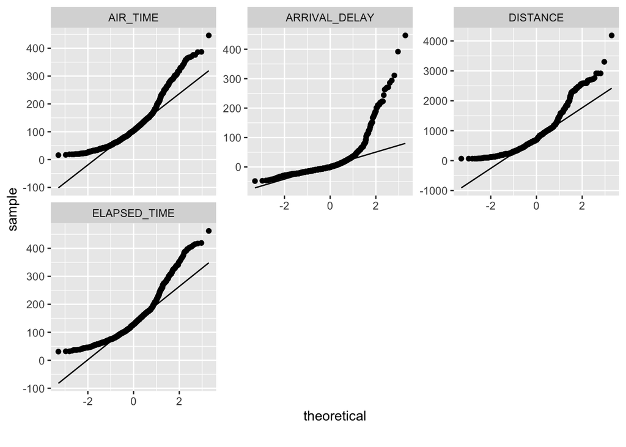

```r
qq_christmas15 <- christmas15[, c("ARRIVAL_DELAY", "AIR_TIME", "DISTANCE", "ELAPSED_TIME")]
plot_qq(qq_christmas15, sampled_rows = 1000L)
```

**QQ-Plots with log**

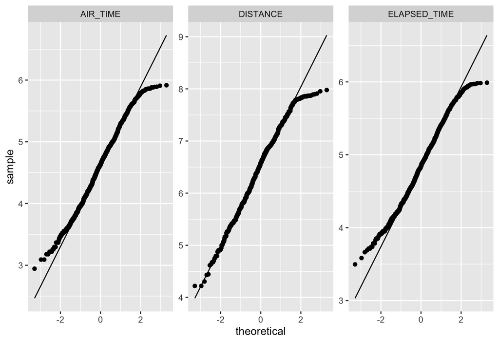

```r
log_qq_christmas15 <- update_columns(qq_christmas15, 2:4, function(x) log(x + 1))

plot_qq(log_qq_christmas15[, 2:4], sampled_rows = 1000L)
```

**Correlations**

```r
christmas15 %>%
  filter(ORIGIN_AIRPORT == "JFK")
```

```
## # A tibble: 1,045 x 34
##       X1 ORIGIN_AIRPORT AIRLINE  YEAR MONTH   DAY DAY_OF_WEEK FLIGHT_NUMBER
##    <dbl> <chr>          <chr>   <dbl> <dbl> <dbl>       <dbl>         <dbl>
##  1 25034 JFK            DL       2015    12    25           5          2808
##  2 25035 JFK            AS       2015    12    23           3             7
##  3 25036 JFK            AA       2015    12    26           6            67
##  4 25037 JFK            B6       2015    12    26           6            65
##  5 25038 JFK            AA       2015    12    25           5           938
##  6 25039 JFK            B6       2015    12    23           3           403
##  7 25040 JFK            B6       2015    12    24           4            15
##  8 25041 JFK            B6       2015    12    25           5          1418
##  9 25042 JFK            B6       2015    12    23           3           983
## 10 25043 JFK            B6       2015    12    25           5          1415
## # … with 1,035 more rows, and 26 more variables: TAIL_NUMBER <chr>,
## #   DESTINATION_AIRPORT <chr>, SCHEDULED_DEPARTURE <chr>,
## #   DEPARTURE_TIME <chr>, DEPARTURE_DELAY <dbl>, TAXI_OUT <dbl>,
## #   WHEELS_OFF <chr>, SCHEDULED_TIME <dbl>, ELAPSED_TIME <dbl>,
## #   AIR_TIME <dbl>, DISTANCE <dbl>, WHEELS_ON <chr>, TAXI_IN <dbl>,
## #   SCHEDULED_ARRIVAL <chr>, ARRIVAL_TIME <chr>, ARRIVAL_DELAY <dbl>,
## #   DIVERTED <dbl>, CANCELLED <dbl>, AIRLINE.y <chr>, AIRPORT <chr>,
## #   CITY <chr>, STATE <chr>, COUNTRY <chr>, LATITUDE <dbl>,
## #   LONGITUDE <dbl>, DEPARTURE_DATE <date>
```

```
## 14 features with more than 5 categories ignored!
## ORIGIN_AIRPORT: 304 categories
## AIRLINE: 13 categories
## TAIL_NUMBER: 4123 categories
## DESTINATION_AIRPORT: 307 categories
## SCHEDULED_DEPARTURE: 1146 categories
## DEPARTURE_TIME: 1331 categories
## WHEELS_OFF: 1336 categories
## WHEELS_ON: 1412 categories
## SCHEDULED_ARRIVAL: 1294 categories
## ARRIVAL_TIME: 1416 categories
## AIRLINE.y: 13 categories
## AIRPORT: 304 categories
## CITY: 292 categories
## STATE: 53 categories
```

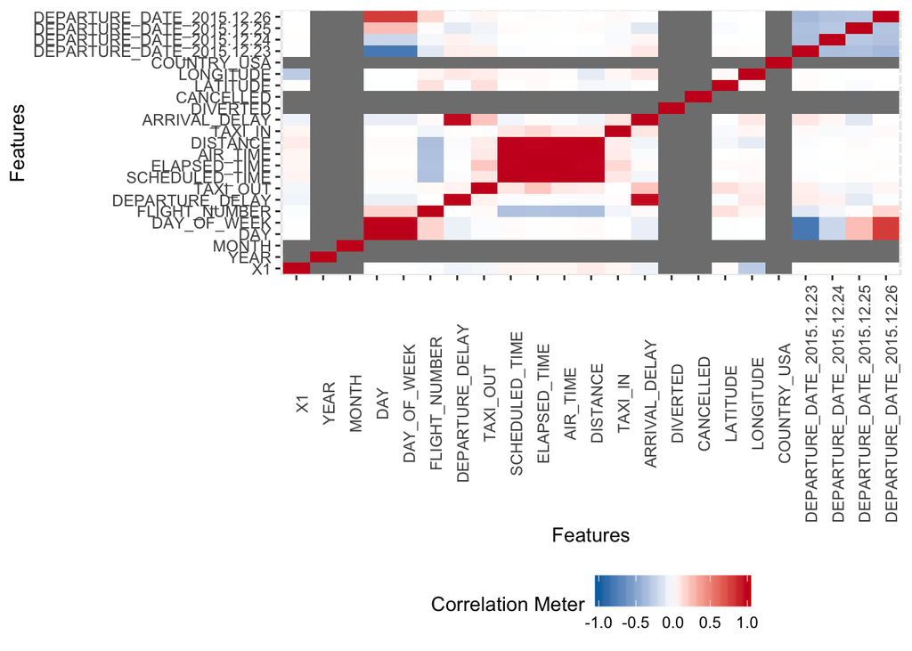

```r
  plot_correlation(na.omit(christmas15), maxcat = 5L)
```

Based on the correlations, a regression analysis can be conducted. Following code chunk is exemplary for a regression analysis. Before that, tests for normal distribution and multicolinearity should be conducted.

**Linear Regression**

```r
lm(ARRIVAL_DELAY ~ DISTANCE + TAXI_IN + TAXI_OUT + DEPARTURE_DELAY + DEPARTURE_DATE, data = christmas15)
```

```
##
## Call:
## lm(formula = ARRIVAL_DELAY ~ DISTANCE + TAXI_IN + TAXI_OUT +
##     DEPARTURE_DELAY + DEPARTURE_DATE, data = christmas15)
##
## Coefficients:
##     (Intercept)         DISTANCE          TAXI_IN         TAXI_OUT
##       6.716e+03       -4.545e-03        7.672e-01        9.117e-01
## DEPARTURE_DELAY   DEPARTURE_DATE
##       9.975e-01       -4.012e-01
```

# 3. Interesting aspects for a dashboard

The object of this project is the develop a Shiny dashborad. Therefore the statistical analysis was shortend. In this part intresting aspect for a Shiny Dashboard are calculated:

**DEPARTURE_DELAY per DAY**

```r
christmas15 %>%
  group_by(DEPARTURE_DATE) %>%
  summarise(DEPARTURE_DELAY = mean(DEPARTURE_DELAY)) %>%
  ungroup() %>%
  arrange(desc(DEPARTURE_DELAY))
```

```
## # A tibble: 4 x 2
##   DEPARTURE_DATE DEPARTURE_DELAY
##   <date>                   <dbl>
## 1 2015-12-23               22.8
## 2 2015-12-24               21.9
## 3 2015-12-26               16.4
## 4 2015-12-25                7.93
```

**DEPARTURE_DELAY per DAY AND AIRLINE**

```r
christmas15 %>%
  group_by(DEPARTURE_DATE, AIRLINE.y) %>%
  summarise(DEPARTURE_DELAY = mean(DEPARTURE_DELAY)) %>%
  ungroup() %>%
  arrange(desc(DEPARTURE_DELAY))
```

```
## # A tibble: 52 x 3
##    DEPARTURE_DATE AIRLINE.y                   DEPARTURE_DELAY
##    <date>         <chr>                                 <dbl>
##  1 2015-12-24     Delta Air Lines Inc.                   76.7
##  2 2015-12-23     JetBlue Airways                        39.9
##  3 2015-12-24     Atlantic Southeast Airlines            39.9
##  4 2015-12-26     Spirit Air Lines                       32.4
##  5 2015-12-26     Frontier Airlines Inc.                 29.0
##  6 2015-12-24     Frontier Airlines Inc.                 27.4
##  7 2015-12-23     Atlantic Southeast Airlines            27.2
##  8 2015-12-23     Skywest Airlines Inc.                  25.1
##  9 2015-12-23     Southwest Airlines Co.                 25.0
## 10 2015-12-24     Spirit Air Lines                       24.8
## # … with 42 more rows
```

**DEPARTURE_DELAY per AIRLINE (Chrismas Delay)**

```r
christmas15 %>%
  group_by(AIRLINE.y) %>%
  summarise(DEPARTURE_DELAY = mean(DEPARTURE_DELAY)) %>%
  ungroup() %>%
  arrange(desc(DEPARTURE_DELAY))
```

```
## # A tibble: 13 x 2
##    AIRLINE.y                    DEPARTURE_DELAY
##    <chr>                                  <dbl>
##  1 Delta Air Lines Inc.                   30.5
##  2 Spirit Air Lines                       23.4
##  3 JetBlue Airways                        21.7
##  4 Frontier Airlines Inc.                 21.3
##  5 Atlantic Southeast Airlines            20.4
##  6 Skywest Airlines Inc.                  18.2
##  7 Southwest Airlines Co.                 17.3
##  8 United Air Lines Inc.                  15.1
##  9 American Airlines Inc.                 12.1
## 10 American Eagle Airlines Inc.            9.56
## 11 Virgin America                          9.23
## 12 Alaska Airlines Inc.                    1.96
## 13 Hawaiian Airlines Inc.                  1.94
```

**What airports have the highest DEPARTURE_DELAYs?**

```r
christmas15 %>%
  group_by(ORIGIN_AIRPORT) %>%
  summarise(meanDEPARTURE_DELAY = mean(DEPARTURE_DELAY)) %>%
  ungroup() %>%
 arrange(desc(meanDEPARTURE_DELAY))
```

```
## # A tibble: 304 x 2
##    ORIGIN_AIRPORT meanDEPARTURE_DELAY
##    <chr>                        <dbl>
##  1 ASE                           91.5
##  2 BQK                           81.9
##  3 EGE                           79.4
##  4 MGM                           75.1
##  5 OAJ                           74.5
##  6 MQT                           68.2
##  7 AVP                           67.8
##  8 ELM                           66.1
##  9 CSG                           63
## 10 ROA                           59.2
## # … with 294 more rows
```

```r
head(christmas15)
```

```
## # A tibble: 6 x 34
##      X1 ORIGIN_AIRPORT AIRLINE  YEAR MONTH   DAY DAY_OF_WEEK FLIGHT_NUMBER
##   <dbl> <chr>          <chr>   <dbl> <dbl> <dbl>       <dbl>         <dbl>
## 1     1 ABE            EV       2015    12    26           6          5579
## 2     2 ABE            EV       2015    12    24           4          5579
## 3     3 ABE            EV       2015    12    26           6          6021
## 4     4 ABE            EV       2015    12    25           5          5579
## 5     5 ABE            EV       2015    12    23           3          5579
## 6     6 ABE            EV       2015    12    23           3          6144
## # … with 26 more variables: TAIL_NUMBER <chr>, DESTINATION_AIRPORT <chr>,
## #   SCHEDULED_DEPARTURE <chr>, DEPARTURE_TIME <chr>,
## #   DEPARTURE_DELAY <dbl>, TAXI_OUT <dbl>, WHEELS_OFF <chr>,
## #   SCHEDULED_TIME <dbl>, ELAPSED_TIME <dbl>, AIR_TIME <dbl>,
## #   DISTANCE <dbl>, WHEELS_ON <chr>, TAXI_IN <dbl>,
## #   SCHEDULED_ARRIVAL <chr>, ARRIVAL_TIME <chr>, ARRIVAL_DELAY <dbl>,
## #   DIVERTED <dbl>, CANCELLED <dbl>, AIRLINE.y <chr>, AIRPORT <chr>,
## #   CITY <chr>, STATE <chr>, COUNTRY <chr>, LATITUDE <dbl>,
## #   LONGITUDE <dbl>, DEPARTURE_DATE <date>
```

```r
christmas15 %>%
    group_by(DEPARTURE_DATE) %>%
    summarise_at(c("ARRIVAL_DELAY", "DEPARTURE_DELAY"),
                 funs(mean(., na.rm = TRUE), median(., na.rm = TRUE)))
```

```
## # A tibble: 4 x 5
##   DEPARTURE_DATE ARRIVAL_DELAY_m… DEPARTURE_DELAY… ARRIVAL_DELAY_m…
##   <date>                    <dbl>            <dbl>            <dbl>
## 1 2015-12-23                20.8             22.8                 5
## 2 2015-12-24                16.5             21.9                -3
## 3 2015-12-25                 1.48             7.93               -6
## 4 2015-12-26                12.9             16.4                 1
## # … with 1 more variable: DEPARTURE_DELAY_median <dbl>
```

**Overview on arrival and departure delay per airline (2)**

```r
christmas15 %>%
    group_by(AIRLINE) %>%
    summarise_at(c("ARRIVAL_DELAY", "DEPARTURE_DELAY"),
                 funs(mean(., na.rm = TRUE), median(., na.rm = TRUE)))
```

```
## # A tibble: 13 x 5
##    AIRLINE ARRIVAL_DELAY_m… DEPARTURE_DELAY… ARRIVAL_DELAY_m…
##    <chr>              <dbl>            <dbl>            <dbl>
##  1 AA                 9.39             12.1                -1
##  2 AS                -4.00              1.96               -9
##  3 B6                18.0              21.7                 2
##  4 DL                26.2              30.5                 2
##  5 EV                18.0              20.4                -2
##  6 F9                17.5              21.3                 2
##  7 HA                 0.303             1.94               -3
##  8 MQ                 5.05              9.56               -7
##  9 NK                23.0              23.4                 5
## 10 OO                17.6              18.2                 3
## 11 UA                 4.03             15.1                -7
## 12 VX                 5.37              9.23                1
## 13 WN                12.2              17.3                 1
## # … with 1 more variable: DEPARTURE_DELAY_median <dbl>
```

**Flights per airline**

```r
christmas15 %>%
    group_by(AIRLINE, DEPARTURE_DATE) %>%
    summarise(count = n())
```

```
## # A tibble: 52 x 3
## # Groups:   AIRLINE [13]
##    AIRLINE DEPARTURE_DATE count
##    <chr>   <date>         <int>
##  1 AA      2015-12-23      2619
##  2 AA      2015-12-24      2304
##  3 AA      2015-12-25      2295
##  4 AA      2015-12-26      2157
##  5 AS      2015-12-23       485
##  6 AS      2015-12-24       477
##  7 AS      2015-12-25       428
##  8 AS      2015-12-26       453
##  9 B6      2015-12-23       786
## 10 B6      2015-12-24       763
## # … with 42 more rows
```

**Count of delayed flights per airline**

```r
christmas15 %>%
    group_by(AIRLINE, DEPARTURE_DATE) %>%
    filter(DEPARTURE_DELAY > 0) %>%
    summarise(count = n())
```

```
## # A tibble: 52 x 3
## # Groups:   AIRLINE [13]
##    AIRLINE DEPARTURE_DATE count
##    <chr>   <date>         <int>
##  1 AA      2015-12-23      1422
##  2 AA      2015-12-24       842
##  3 AA      2015-12-25       772
##  4 AA      2015-12-26       964
##  5 AS      2015-12-23       151
##  6 AS      2015-12-24        91
##  7 AS      2015-12-25        82
##  8 AS      2015-12-26       128
##  9 B6      2015-12-23       539
## 10 B6      2015-12-24       414
## # … with 42 more rows
```